# Domestic Violence Protection Order Data in Colorado in 2024

Author

Andrew MacFarland (andrew.macfarland@cuanschutz.edu)

Published

April 30, 2026

## *Summary*

This report provides an overview of Colorado’s Domestic Violence Protection Order (DVPO) cases in 2024. It is an exploratory analysis and has not been QA’d or approved for distribution!

### *Case Types and Event Codes*

In 2024, the following event_code(s) were filed per case_type n times. Duplicate case_number(s) within an event_code case_type pairing were removed. “Protection Order Domestic Violence” appears to be a data entry artifact or error and were excluded.

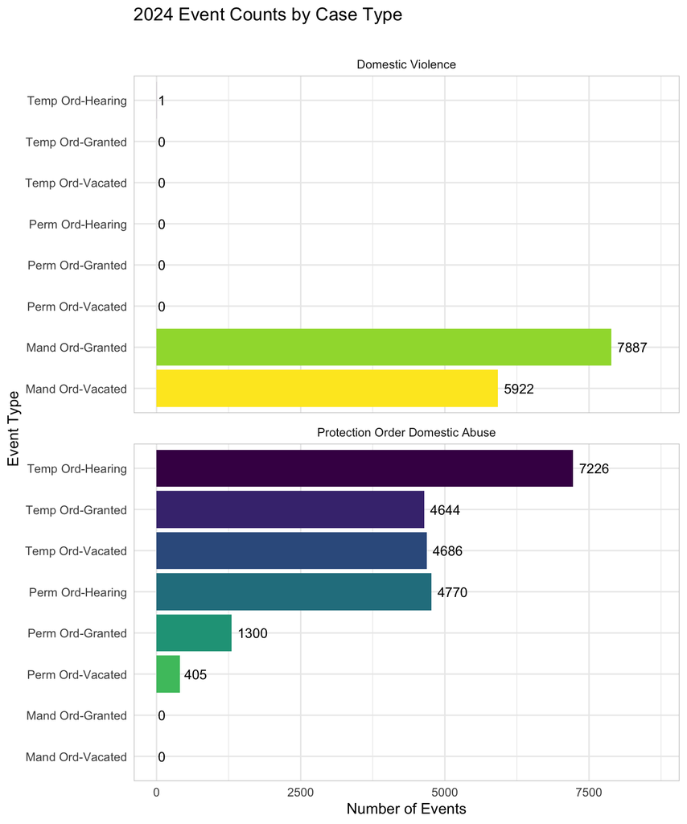

### Case Pathway Analysis

Here we analyze the potential pathways from initial temporary order hearing to final permanent orders (or lack thereof). These data represent events occurring in 2024; some events are from cases that opened before 2024 or closed after 2024. The analysis ignores vacation of temporary protection orders, because there are hundreds of cases that have a permanent order hearing but never got their temp order vacated, so it’s likely that the data are unreliable. We may want to follow up with a local clerk if possible to get more clarity on the process.

[interactive chart not shown]

#### Why the Strange Timing Numbers?

Here is a breakdown of how many days passed between events in the case pathway. Negative numbers indicate that the “first” event occurred after the “second” event (e.g., the temporary protectionorder was recorded as being granted BEFORE the initial temporary protection order hearing). Zero values were removed from histogram plots to highlight non-zero values, number of zero values noted in footnote of each plot.

Timing between Temporary Protection Order Hearing and Temporary Protection Order Granted

| avg_days | min_days | max_days | sd_days |
| --- | --- | --- | --- |
| −0.5 | −161.0 | 318.0 | 8.7 |

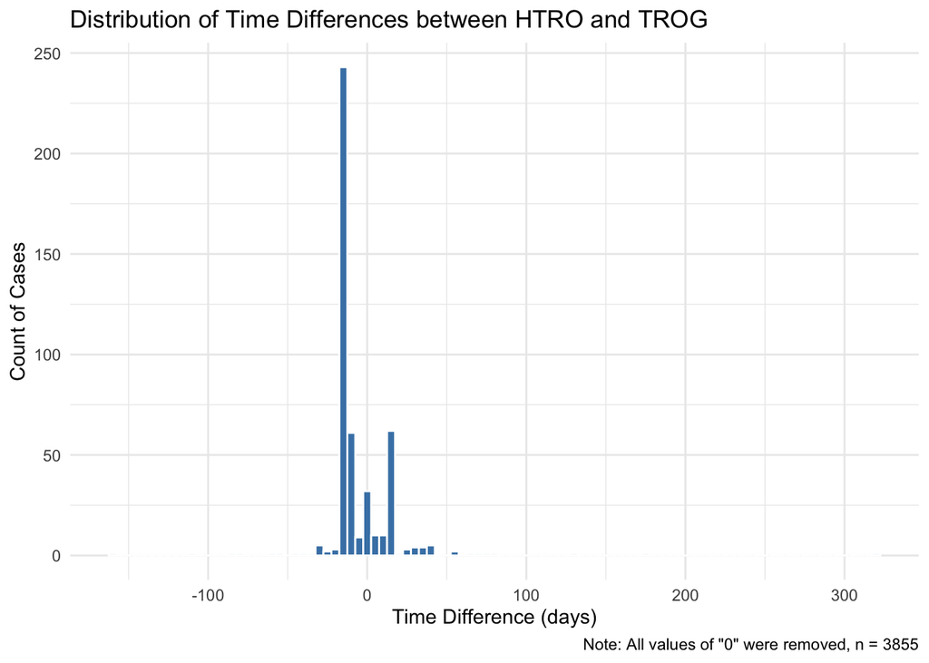

Timing between Temporary Protection Order Granted and Permanent Protection Order Hearing

| avg_days | min_days | max_days | sd_days |
| --- | --- | --- | --- |
| 17.2 | −126.0 | 344.0 | 19.5 |

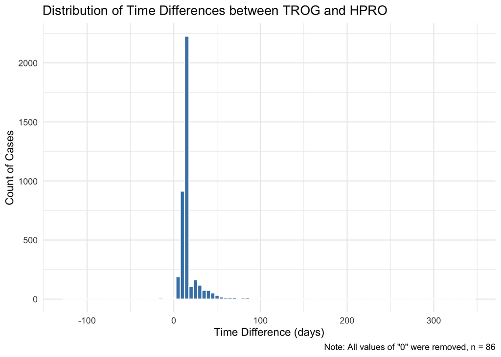

Timing between Permanent Protection Order Hearing and Permanent Protection Order Granted

| avg_days | min_days | max_days | sd_days |
| --- | --- | --- | --- |
| 7.3 | −199.0 | 316.0 | 24.9 |

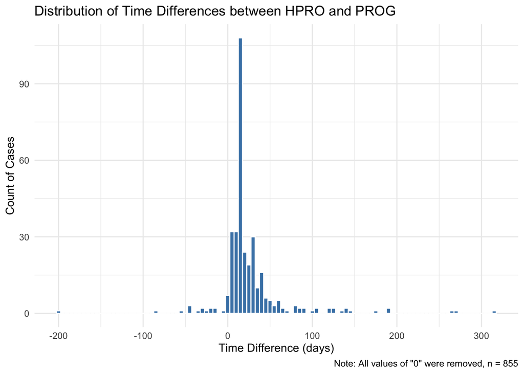

#### Timing by County

Breakdown of timing between temporary protection order hearing and temporary protection order granted by county. SD values are missing for counties with only 1 case with both HTRO and TROG events. Counties without a single case with both HTRO and TROG events are not included in the table.

Timing between Temporary Protection Order Hearing and Temporary Protection Order Granted by County

| county_name | avg_days | min_days | max_days | sd_days | n_cases |
| --- | --- | --- | --- | --- | --- |
| Las Animas County | −15.0 | −15.0 | −15.0 | Missing | 1 |
| Mesa County | −11.5 | −161.0 | 318.0 | 22.8 | 303 |
| Morgan County | −8.0 | −8.0 | −8.0 | Missing | 1 |
| Fremont County | −7.8 | −79.0 | 173.0 | 28.2 | 76 |
| Kit Carson County | −2.7 | −8.0 | 0.0 | 4.6 | 3 |
| Moffat County | −2.3 | −14.0 | 0.0 | 4.8 | 15 |
| Chaffee County | −1.9 | −14.0 | 7.0 | 6.9 | 10 |
| Boulder Cty-Longmont | −1.6 | −85.0 | 0.0 | 11.2 | 58 |
| Saguache County | −0.1 | −1.0 | 0.0 | 0.4 | 8 |
| Pueblo County | 0.0 | −3.0 | 0.0 | 0.2 | 214 |
| Alamosa County | 0.0 | 0.0 | 0.0 | 0.0 | 13 |
| Arapahoe Cty-Littleton | 0.0 | 0.0 | 0.0 | 0.0 | 61 |
| Archuleta County | 0.0 | 0.0 | 0.0 | 0.0 | 23 |
| Bent County | 0.0 | 0.0 | 0.0 | 0.0 | 17 |
| Boulder County | 0.0 | 0.0 | 0.0 | 0.0 | 81 |
| Broomfield County | 0.0 | 0.0 | 0.0 | 0.0 | 22 |
| Cheyenne County | 0.0 | 0.0 | 0.0 | 0.0 | 4 |
| Conejos County | 0.0 | 0.0 | 0.0 | 0.0 | 3 |
| Costilla County | 0.0 | 0.0 | 0.0 | 0.0 | 4 |
| Crowley County | 0.0 | 0.0 | 0.0 | 0.0 | 8 |
| Dolores County | 0.0 | 0.0 | 0.0 | 0.0 | 5 |
| Elbert County | 0.0 | 0.0 | 0.0 | 0.0 | 4 |
| Gilpin County | 0.0 | 0.0 | 0.0 | Missing | 1 |
| Gunnison County | 0.0 | 0.0 | 0.0 | 0.0 | 2 |
| La Plata County | 0.0 | 0.0 | 0.0 | 0.0 | 66 |
| Lincoln County | 0.0 | 0.0 | 0.0 | 0.0 | 7 |
| Mineral County | 0.0 | 0.0 | 0.0 | Missing | 1 |
| Montrose County-Nucla | 0.0 | 0.0 | 0.0 | Missing | 1 |
| Otero County | 0.0 | 0.0 | 0.0 | 0.0 | 68 |
| Pitkin County | 0.0 | 0.0 | 0.0 | 0.0 | 3 |
| Rio Blanco County, Rangely | 0.0 | 0.0 | 0.0 | Missing | 1 |
| Rio Grande County | 0.0 | 0.0 | 0.0 | 0.0 | 5 |
| Routt County | 0.0 | 0.0 | 0.0 | 0.0 | 7 |
| San Miguel County | 0.0 | 0.0 | 0.0 | 0.0 | 4 |
| El Paso County | 0.0 | 0.0 | 4.0 | 0.1 | 1,285 |
| Arapahoe County | 0.0 | 0.0 | 2.0 | 0.2 | 200 |
| Prowers County | 0.0 | 0.0 | 1.0 | 0.2 | 44 |
| Montrose County | 0.0 | 0.0 | 1.0 | 0.2 | 21 |
| Weld County | 0.1 | 0.0 | 14.0 | 0.7 | 452 |
| Adams County | 0.1 | 0.0 | 14.0 | 1.2 | 540 |
| Garfield County-Rifle | 0.1 | 0.0 | 4.0 | 0.8 | 27 |
| Summit County | 0.2 | 0.0 | 1.0 | 0.4 | 12 |
| Larimer County | 0.2 | −14.0 | 26.0 | 4.0 | 72 |
| Garfield County | 0.2 | 0.0 | 2.0 | 0.6 | 21 |
| Custer County | 0.3 | 0.0 | 1.0 | 0.6 | 3 |
| Park County | 0.7 | 0.0 | 3.0 | 1.2 | 6 |
| Baca County | 1.0 | 0.0 | 2.0 | 1.4 | 2 |
| Grand County | 2.3 | 0.0 | 14.0 | 5.7 | 6 |
| Douglas County | 2.4 | 0.0 | 74.0 | 9.7 | 116 |
| Jefferson County | 2.8 | −33.0 | 54.0 | 7.8 | 338 |
| Delta County | 3.2 | 0.0 | 38.0 | 11.0 | 12 |
| Teller County | 4.1 | 0.0 | 71.0 | 13.4 | 38 |
| Montezuma County | 9.9 | 0.0 | 82.0 | 18.8 | 32 |

### *Cases by County*

Here are plots of the top 15 counties by dvpo case filings in 2024 (by count and by rate). Absent is Denver County, cases from which are not included in the data. These data include temp hearings, temp orders granted, perm order hearings, and perm order hearings.

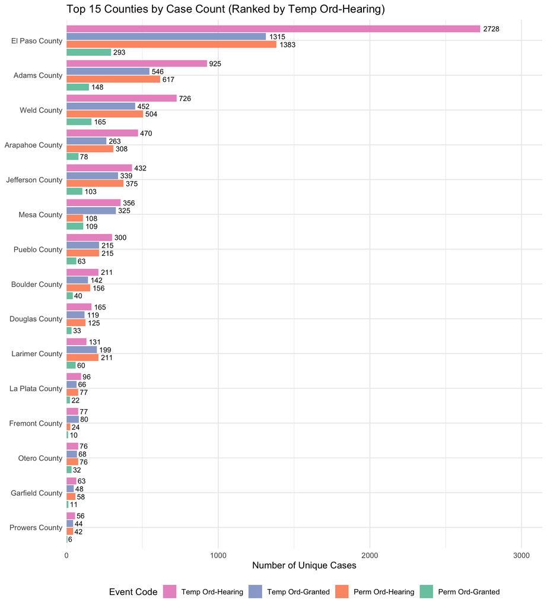

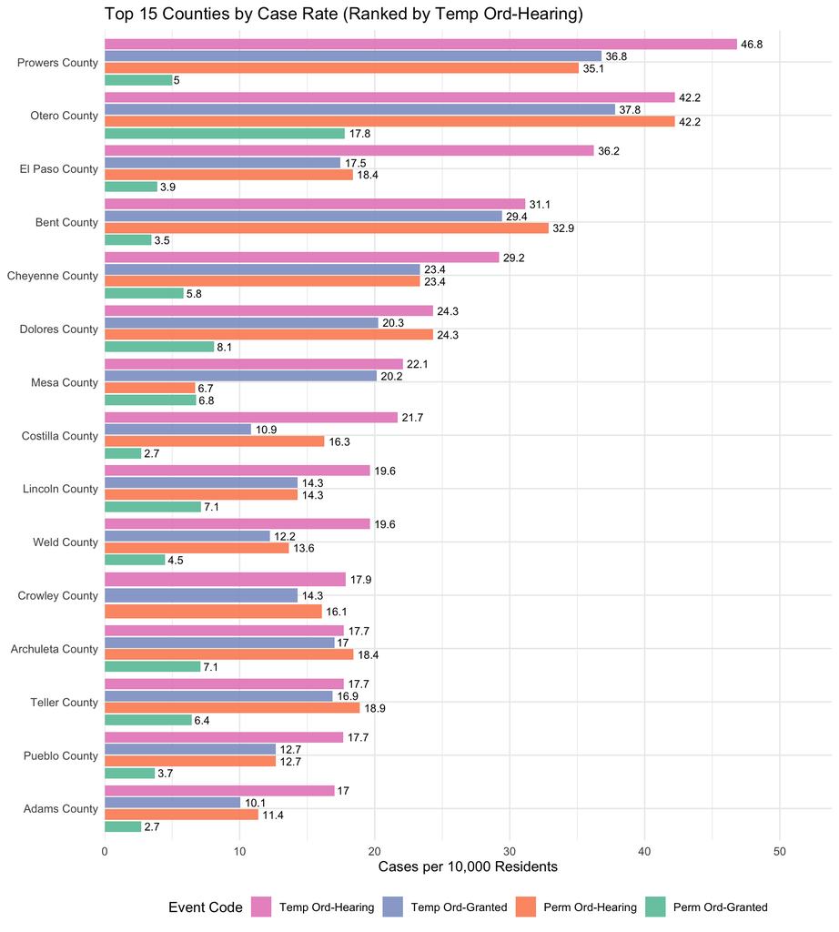

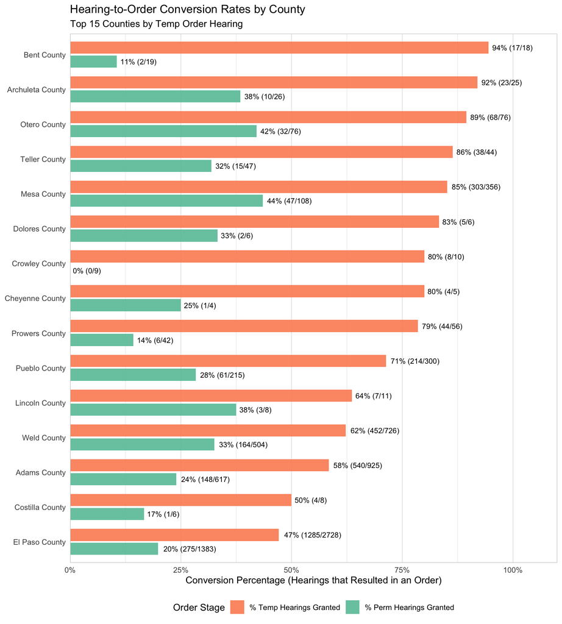

*Annual Estimates of the Resident Population for Counties in Colorado: April 1, 2020 to July 1, 2024 (CO-EST2024-POP-08). Source: U.S. Census Bureau, Population Division. Release Date: March 2025.*